# Cleaning Clinical Research Data in R

- Show All Code
- Hide All Code
- View Source

How to turn a messy spreadsheet into an analysis-ready dataset

Author

Ziyao Geng, RISE Education Team

**NoteHow to use this article**

This article builds on Article 1. It assumes that you can open RStudio, run code chunks, load packages, import a CSV file, inspect a dataset, and read simple pipe-based code.

The goal here is to learn how to clean a messy research dataset in a reproducible way.

## 1. From clean teaching data to messy real-world data

In Article 1, we used a clean fictional health dataset to learn the basics of R. Real clinical research datasets are rarely that tidy.

A spreadsheet may look organised at first glance, but it can still contain problems that quietly damage the analysis.

Common problems include:

- inconsistent column names;
- missing values;
- duplicate participants;
- inconsistent category labels;
- impossible biological values;
- numbers accidentally stored as text;
- unclear variable coding.

The purpose of data cleaning is not to make the dataset look perfect. The purpose is to make the dataset accurate, consistent, documented, and ready for analysis.

## 2. The core rule: never overwrite the raw dataset

The raw dataset is the original record. Do not overwrite it.

A better workflow is:

1. keep the raw dataset untouched;
2. write cleaning steps in R code;
3. save a separate cleaned dataset;
4. keep a short record of important cleaning decisions.

**TipMain idea**

The raw dataset should stay unchanged. Clean the data using code and save a new cleaned version.

## 3. The messy sample dataset

In this article, we will use a fictional teaching dataset called `rise_sample_health_data_messy.csv`. It is based on the clean dataset from Article 1, but we have deliberately added missing values, inconsistent labels, duplicate participant IDs, and biologically implausible values.

Some of the key variables are shown below.

| Variable | What it represents | Example problem |
| --- | --- | --- |
| `Participant ID` | Participant identifier | Extra spaces and duplicate IDs |
| `Age` | Age in years | Missing values and impossible values |
| `Sex` | Sex recorded in the dataset | `Male`, `male`, `M`, `F`, unclear values |
| `BMI` | Body mass index | Missing values and impossible values |
| `Systolic BP` | Systolic blood pressure | Values such as `142 mmHg` |
| `Diastolic BP` | Diastolic blood pressure | Values such as `82 mmHg` |
| `HbA1c (mmol/mol)` | HbA1c | Values such as `48 mmol/mol` |
| `Smoking Status` | Smoking history | `Never`, `N`, `ex-smoker`, inconsistent labels |
| `Diabetes Status` | Diabetes status | `Yes`, `Y`, `T2DM`, `No`, inconsistent labels |
| `Recruitment Site` | Fictional recruitment location | Inconsistent capitalisation |
| `Study Group` | Fictional study group | Inconsistent capitalisation |
| `Exercise Minutes Per Week` | Self-reported exercise time | Missing values and impossible values |

The aim is to turn this messy raw dataset into an analysis-ready dataset.

## 4. Project folder structure for data cleaning

For data cleaning, we need a slightly more careful folder structure than in Article 1.

```
article_02_data_cleaning_in_r/
├── article_02_cleaning_clinical_research_data.qmd
├── data_raw/
│   └── rise_sample_health_data_messy.csv
├── data_cleaned/
│   └── rise_sample_health_data_cleaned.csv
├── scripts/
│   └── article_02_cleaning_code.R
└── outputs/
    ├── data_cleaning_summary.csv
    ├── duplicate_participant_report.csv
    ├── missing_values_before_cleaning.csv
    ├── missing_values_after_cleaning.csv
    ├── suspicious_values_report.csv
    └── variable_dictionary.csv
```

The key idea is simple:

- `data_raw/` contains the original dataset;
- `data_cleaned/` contains the cleaned dataset;
- `scripts/` contains reusable R code;
- `outputs/` contains reports generated during cleaning.

For the file paths in this article to work, the Quarto file should be saved inside the main article folder shown above.

## 5. Load packages and create folders

We will use two main packages.

- `tidyverse` helps us import, clean, summarise, and visualise data.
- `janitor` helps us clean column names and create quick tables.

```r
# Run this only if the packages are not already installed.
install.packages("tidyverse")
install.packages("janitor")
```

```r
# Load packages for this session.
library(tidyverse)
library(janitor)

# Create project folders if they do not already exist.
dir.create("data_raw", showWarnings = FALSE)
dir.create("data_cleaned", showWarnings = FALSE)
dir.create("outputs", showWarnings = FALSE)
```

## 6. Import the raw dataset safely

In a messy dataset, it is often useful to import everything as text first. This prevents R from guessing variable types too early.

For example, a value like `142 mmHg` is not a pure number. If we import the dataset too aggressively, R may make choices that are difficult to diagnose later. A safer beginner-friendly approach is to import first, inspect, clean, and then convert variable types.

```r
# Store the file path of the raw messy dataset.
raw_data_path <- "data_raw/rise_sample_health_data_messy.csv"

# Check whether the raw dataset exists.
if (!file.exists(raw_data_path)) {
  stop("Cannot find the raw dataset. Check that it is inside the data_raw/ folder.")
}

# Read the raw CSV file into R.
raw_data <- read_csv(
  file = raw_data_path,

  # Read all columns as text first.
  col_types = cols(.default = col_character()),

  # Treat these entries as missing values.
  na = c("", "NA", "N/A", "Unknown", "Not recorded", "not available")
)
```

At this stage, `raw_data` should be treated as the untouched raw dataset.

## 7. Inspect the raw dataset

Before we start cleaning, we should inspect the dataset. This helps us identify obvious problems before making changes.

```r
# Show the first few rows.
head(raw_data)
```

```
# A tibble: 6 × 12
  `Participant ID` Age   Sex    BMI   `Systolic BP` `Diastolic BP`
  <chr>            <chr> <chr>  <chr> <chr>         <chr>
1 RISE001          56    woman  20.0  129           73
2 RISE002          69    female 19.5  132           89
3 RISE003          72    Male   27.3  152           69
4 RISE004          250   female 27.7  117           67 mmHg
5 RISE005          29    man    25.3  114 mmHg      67 mmHg
6 RISE006          19    Female 26.7  122           80
# ℹ 6 more variables: `HbA1c (mmol/mol)` <chr>, `Smoking Status` <chr>,
#   `Diabetes Status` <chr>, `Recruitment Site` <chr>, `Study Group` <chr>,
#   `Exercise Minutes Per Week` <chr>
```

```r
# Show variable names, types, and example values.
glimpse(raw_data)
```

```
Rows: 85
Columns: 12
$ `Participant ID`            <chr> "RISE001", "RISE002", "RISE003", "RISE004"…
$ Age                         <chr> "56", "69", "72", "250", "29", "19", "67",…
$ Sex                         <chr> "woman", "female", "Male", "female", "man"…
$ BMI                         <chr> "20.0", "19.5", "27.3", "27.7", "25.3", "2…
$ `Systolic BP`               <chr> "129", "132", "152", "117", "114 mmHg", "1…
$ `Diastolic BP`              <chr> "73", "89", "69", "67 mmHg", "67 mmHg", "8…
$ `HbA1c (mmol/mol)`          <chr> "35.0", "57.9", "66.3", "39.4", "34.1", "3…
$ `Smoking Status`            <chr> "never", "Never smoker", "former", "ex-smo…
$ `Diabetes Status`           <chr> "No diabetes", "Yes", "T2DM", "No diabetes…
$ `Recruitment Site`          <chr> "Metro Hospital", "Metro Hospital", "Regio…
$ `Study Group`               <chr> "Control", "Control", "Control", "Control"…
$ `Exercise Minutes Per Week` <chr> "292.0", "54.0", "22.0", "240.0", "259.0",…
```

```r
# Check the number of rows and columns.
dim(raw_data)
```

```
[1] 85 12
```

```r
# Check the original column names.
names(raw_data)
```

```
 [1] "Participant ID"            "Age"
 [3] "Sex"                       "BMI"
 [5] "Systolic BP"               "Diastolic BP"
 [7] "HbA1c (mmol/mol)"          "Smoking Status"
 [9] "Diabetes Status"           "Recruitment Site"
[11] "Study Group"               "Exercise Minutes Per Week"
```

## 8. Clean column names

Raw clinical spreadsheets often have column names with spaces, capital letters, brackets, or symbols.

R can work with those names, but they are awkward to type. We can use `clean_names()` from the `janitor` package to make them easier to use.

```r
# Create a working copy of the raw dataset.
# The raw dataset itself remains unchanged.
clean_data <- raw_data %>%
  clean_names()

# Check the cleaned column names.
names(clean_data)
```

```
 [1] "participant_id"            "age"
 [3] "sex"                       "bmi"
 [5] "systolic_bp"               "diastolic_bp"
 [7] "hb_a1c_mmol_mol"           "smoking_status"
 [9] "diabetes_status"           "recruitment_site"
[11] "study_group"               "exercise_minutes_per_week"
```

For example:

```
Participant ID        -> participant_id
Systolic BP           -> systolic_bp
HbA1c (mmol/mol)      -> hb_a1c_mmol_mol
```

For consistency in this teaching series, we will rename `hb_a1c_mmol_mol` to `hba1c_mmol_mol`.

```r
# Rename one column to make the naming style simpler.
clean_data <- clean_data %>%
  rename(hba1c_mmol_mol = hb_a1c_mmol_mol)

# Check that the renaming worked.
names(clean_data)
```

```
 [1] "participant_id"            "age"
 [3] "sex"                       "bmi"
 [5] "systolic_bp"               "diastolic_bp"
 [7] "hba1c_mmol_mol"            "smoking_status"
 [9] "diabetes_status"           "recruitment_site"
[11] "study_group"               "exercise_minutes_per_week"
```

In `rename()`, the new name goes on the left and the old name goes on the right.

## 9. Count missing values before cleaning

Before we clean the dataset, it is useful to count how many missing values are present in each variable. This gives us a baseline record before we make further changes.

In R, missing values are usually shown as `NA`, which stands for “not available”. Missing values are common in clinical and research datasets. For example, a participant may not have answered a question, a blood test may not have been performed, or a value may have been entered incorrectly and later removed.

To count missing values, we can use `is.na()`. This function checks whether each value is missing. It returns `TRUE` for missing values and `FALSE` for non-missing values.

For example:

```r
# Check whether each age value is missing.
is.na(clean_data$age)
```

```
 [1] FALSE FALSE FALSE FALSE FALSE FALSE FALSE FALSE FALSE FALSE FALSE FALSE
[13] FALSE FALSE FALSE FALSE FALSE FALSE FALSE FALSE FALSE FALSE FALSE FALSE
[25] FALSE FALSE FALSE FALSE  TRUE FALSE FALSE FALSE FALSE FALSE FALSE FALSE
[37] FALSE FALSE FALSE FALSE FALSE FALSE FALSE FALSE FALSE FALSE FALSE FALSE
[49] FALSE FALSE FALSE FALSE FALSE FALSE FALSE FALSE FALSE FALSE FALSE FALSE
[61] FALSE FALSE FALSE FALSE FALSE FALSE FALSE FALSE FALSE FALSE FALSE FALSE
[73] FALSE  TRUE FALSE FALSE FALSE FALSE FALSE FALSE FALSE FALSE FALSE FALSE
[85] FALSE
```

However, we usually do not want to check only one variable at a time. Instead, we want to count missing values across all variables in the dataset.

```r
# Count missing values in every variable.
missing_before_cleaning <- clean_data %>%
  summarise(across(everything(), ~ sum(is.na(.x)))) %>%
  pivot_longer(
    cols = everything(),
    names_to = "variable",
    values_to = "missing_n"
  ) %>%
  arrange(desc(missing_n))

missing_before_cleaning
```

```
# A tibble: 12 × 2
   variable                  missing_n
   <chr>                         <int>
 1 bmi                               4
 2 hba1c_mmol_mol                    3
 3 diabetes_status                   3
 4 exercise_minutes_per_week         3
 5 age                               2
 6 sex                               2
 7 smoking_status                    1
 8 participant_id                    0
 9 systolic_bp                       0
10 diastolic_bp                      0
11 recruitment_site                  0
12 study_group                       0
```

Let’s break this down.

```r
summarise(across(everything(), ~ sum(is.na(.x))))
```

This part goes through every variable in the dataset and counts how many missing values each variable contains.

The result at this stage is a wide table. This means each variable is shown as a separate column.

However, this format is not very convenient for reading or sorting. Therefore, we use `pivot_longer()`.

```r
pivot_longer(
  cols = everything(),
  names_to = "variable",
  values_to = "missing_n"
)
```

`pivot_longer()` reshapes the table from wide format into long format.

Instead of having one column for each variable, we create two columns:

- `variable`: the name of the variable;
- `missing_n`: the number of missing values in that variable.

This makes the result much easier to read, sort, filter, and later report.

Finally:

```r
arrange(desc(missing_n))
```

This sorts the table so that variables with the most missing values appear at the top.

The final table gives us a clear overview of missing data before cleaning. This is useful because it helps us decide which variables need closer inspection and allows us to compare the dataset before and after cleaning.

```r
# Save the before-cleaning missing value report.
write_csv(missing_before_cleaning, "outputs/missing_values_before_cleaning.csv")
```

## 10. Clean participant IDs and extra spaces

```r
# Clean text values in the dataset.
clean_data <- clean_data %>%
  mutate(
    # Remove extra spaces from participant IDs.
    participant_id = str_squish(participant_id),

    # Convert participant IDs to uppercase.
    participant_id = str_to_upper(participant_id),

    # Remove extra spaces from all text columns.
    across(where(is.character), str_squish)
  )
```

This step:

- removes repeated spaces;
- removes spaces at the start and end of text;
- standardises participant IDs to uppercase.

## 11. Check duplicate participants

A duplicate participant ID means the same participant appears more than once in the dataset.

This may happen because of accidental repeated data entry, but it may also happen for valid reasons, such as repeated clinic visits or follow-up measurements. Therefore, we should always check duplicates before removing anything.

```r
# Count how many rows each participant ID has.
duplicate_participants <- clean_data %>%
  count(participant_id, name = "n_rows") %>%

  # Keep only IDs that appear more than once.
  filter(n_rows > 1)

# Print the duplicate participant report.
duplicate_participants
```

```
# A tibble: 5 × 2
  participant_id n_rows
  <chr>           <int>
1 RISE005             2
2 RISE011             2
3 RISE021             2
4 RISE036             2
5 RISE051             2
```

Save this report before removing duplicates. This gives us a record of what was identified, which is useful for transparency and reproducibility.

```r
# Save the duplicate participant report.
write_csv(duplicate_participants, "outputs/duplicate_participant_report.csv")
```

For this teaching dataset, we will keep the first row for each participant. This is a simple approach for demonstration, but in real research you should inspect duplicates carefully before deciding what to remove.

```r
# Count rows before removing duplicate participants.
n_before_duplicates <- nrow(clean_data)

# Remove duplicate participant IDs.
clean_data <- clean_data %>%
  distinct(participant_id, .keep_all = TRUE)

# Count rows after removing duplicate participants.
n_after_duplicates <- nrow(clean_data)

n_after_duplicates
```

```
[1] 80
```

**WarningBe careful in real research**

In real clinical data, duplicate IDs are not always errors. They may represent repeated visits, multiple admissions, or longitudinal follow-up. Always check the study design before removing duplicates.

## 12. Convert numeric variables

Some values look numeric but are actually stored as text. For example, `142 mmHg` is text, not a number.

The function `parse_number()` extracts the numeric part from a text value.

```r
# Convert selected variables from text into numbers.
clean_data <- clean_data %>%
  mutate(
    # Extract the numeric part of age.
    age = parse_number(age),

    # Extract the numeric part of BMI.
    bmi = parse_number(bmi),

    # Extract the numeric part of systolic BP.
    systolic_bp = parse_number(systolic_bp),

    # Extract the numeric part of diastolic BP.
    diastolic_bp = parse_number(diastolic_bp),

    # Extract the numeric part of HbA1c.
    hba1c_mmol_mol = parse_number(hba1c_mmol_mol),

    # Extract the numeric part of exercise minutes.
    exercise_minutes_per_week = parse_number(exercise_minutes_per_week)
  )
```

Numeric variables are needed for means, medians, plots, and statistical tests.

**NoteWhy not convert everything automatically?**

In beginner projects, it is safer to convert variables deliberately. This makes it clearer which variables should be numeric and prevents accidental conversion of identifiers or category labels.

## 13. Standardise categorical variables

Categorical variables often contain inconsistent labels.

For example, the same idea may be recorded as `Male`, `male`, `M`, or `man`.

This is a problem because R treats these as different categories. Before analysis, we should standardise them into a smaller set of consistent labels.

We can do this using:

- `str_to_lower()` to make text lowercase before matching;
- `case_when()` to convert different versions of the same answer into one standard label.

```r
# Standardise categorical variables.
clean_data <- clean_data %>%
  mutate(
    # Convert sex values to lowercase first.
    sex = str_to_lower(sex),

    # Recode sex into standard labels.
    sex = case_when(
      sex %in% c("male", "m", "man") ~ "Male",
      sex %in% c("female", "f", "woman") ~ "Female",
      TRUE ~ NA_character_
    ),

    # Convert diabetes status values to lowercase first.
    diabetes_status = str_to_lower(diabetes_status),

    # Recode diabetes status into standard labels.
    diabetes_status = case_when(
      diabetes_status %in% c("yes", "y", "t2dm", "type 2 diabetes", "diabetes") ~ "Yes",
      diabetes_status %in% c("no", "n", "no diabetes") ~ "No",
      TRUE ~ NA_character_
    ),

    # Convert smoking status values to lowercase first.
    smoking_status = str_to_lower(smoking_status),

    # Recode smoking status into standard labels.
    smoking_status = case_when(
      smoking_status %in% c("never", "n", "never smoker") ~ "Never",
      smoking_status %in% c("former", "ex-smoker", "past smoker") ~ "Former",
      smoking_status %in% c("current", "c", "smoker") ~ "Current",
      TRUE ~ NA_character_
    ),

    # Convert recruitment site to title case.
    recruitment_site = str_to_title(recruitment_site),

    # Convert study group to title case.
    study_group = str_to_title(study_group)
  )
```

Check the cleaned categories.

```r
# Count participants by sex.
clean_data %>% count(sex)
```

```
# A tibble: 3 × 2
  sex        n
  <chr>  <int>
1 Female    45
2 Male      33
3 <NA>       2
```

```r
# Count participants by diabetes status.
clean_data %>% count(diabetes_status)
```

```
# A tibble: 3 × 2
  diabetes_status     n
  <chr>           <int>
1 No                 55
2 Yes                23
3 <NA>                2
```

```r
# Count participants by smoking status.
clean_data %>% count(smoking_status)
```

```
# A tibble: 4 × 2
  smoking_status     n
  <chr>          <int>
1 Current           10
2 Former            17
3 Never             52
4 <NA>               1
```

The `NA` values remain because some participants either had missing values in the original dataset or had values that were not included in our recoding rules. This is expected. In real research, we should inspect these values carefully before deciding whether to keep them as missing, correct them manually, or add more recoding rules.

**TipWhat does `TRUE ~ NA_character_` mean?**

In `case_when()`, `TRUE ~ NA_character_` means: if a value does not match any of the rules above, turn it into a missing text value.

This is useful in a teaching example, but in real research you should inspect unmatched values before converting them to missing.

## 14. Check impossible or suspicious values

This is where medical judgement matters. Some values may be technically numeric but biologically implausible.

For this teaching dataset, we will use simple example cut-offs.

In the code below, each `filter()` statement identifies rows with suspicious values for one variable. Then `transmute()` creates a small report showing the participant ID, the variable name, the suspicious value, and the reason it was flagged. Finally, `bind_rows()` combines all of these small reports into one table.

```r
# Create a report of suspicious values.
suspicious_values <- bind_rows(

  # Check age values.
  clean_data %>%
    filter(age < 0 | age > 120) %>%
    transmute(
      participant_id,
      variable = "age",
      value = as.character(age),
      reason = "Age outside 0-120"
    ),

  # Check BMI values.
  clean_data %>%
    filter(bmi < 10 | bmi > 80) %>%
    transmute(
      participant_id,
      variable = "bmi",
      value = as.character(bmi),
      reason = "BMI outside 10-80"
    ),

  # Check systolic blood pressure values.
  clean_data %>%
    filter(systolic_bp < 70 | systolic_bp > 250) %>%
    transmute(
      participant_id,
      variable = "systolic_bp",
      value = as.character(systolic_bp),
      reason = "Systolic BP outside 70-250"
    ),

  # Check diastolic blood pressure values.
  clean_data %>%
    filter(diastolic_bp < 40 | diastolic_bp > 150) %>%
    transmute(
      participant_id,
      variable = "diastolic_bp",
      value = as.character(diastolic_bp),
      reason = "Diastolic BP outside 40-150"
    ),

  # Check HbA1c values.
  clean_data %>%
    filter(hba1c_mmol_mol < 15 | hba1c_mmol_mol > 160) %>%
    transmute(
      participant_id,
      variable = "hba1c_mmol_mol",
      value = as.character(hba1c_mmol_mol),
      reason = "HbA1c outside 15-160"
    ),

  # Check exercise minutes.
  clean_data %>%
    filter(exercise_minutes_per_week < 0 | exercise_minutes_per_week > 2000) %>%
    transmute(
      participant_id,
      variable = "exercise_minutes_per_week",
      value = as.character(exercise_minutes_per_week),
      reason = "Exercise minutes outside 0-2000"
    )
)

# Print the suspicious values report.
suspicious_values
```

```
# A tibble: 7 × 4
  participant_id variable                  value reason
  <chr>          <chr>                     <chr> <chr>
1 RISE004        age                       250   Age outside 0-120
2 RISE010        bmi                       5     BMI outside 10-80
3 RISE016        systolic_bp               310   Systolic BP outside 70-250
4 RISE022        diastolic_bp              20    Diastolic BP outside 40-150
5 RISE028        hba1c_mmol_mol            220   HbA1c outside 15-160
6 RISE034        exercise_minutes_per_week -30   Exercise minutes outside 0-2000
7 RISE042        exercise_minutes_per_week 5000  Exercise minutes outside 0-2000
```

```r
# Save the suspicious values report.
write_csv(suspicious_values, "outputs/suspicious_values_report.csv")
```

**ImportantTeaching example only**

These cut-offs are used for teaching. In real research, plausibility rules should be discussed with supervisors, clinicians, statisticians, or the study protocol.

## 15. Replace impossible values with missing values

After creating a report, we can replace impossible values with `NA`.

```r
# Replace impossible values with missing values.
clean_data <- clean_data %>%
  mutate(
    # Replace impossible age values.
    age = if_else(age < 0 | age > 120, NA_real_, age),

    # Replace impossible BMI values.
    bmi = if_else(bmi < 10 | bmi > 80, NA_real_, bmi),

    # Replace impossible systolic BP values.
    systolic_bp = if_else(systolic_bp < 70 | systolic_bp > 250, NA_real_, systolic_bp),

    # Replace impossible diastolic BP values.
    diastolic_bp = if_else(diastolic_bp < 40 | diastolic_bp > 150, NA_real_, diastolic_bp),

    # Replace impossible HbA1c values.
    hba1c_mmol_mol = if_else(hba1c_mmol_mol < 15 | hba1c_mmol_mol > 160, NA_real_, hba1c_mmol_mol),

    # Replace impossible exercise minute values.
    exercise_minutes_per_week = if_else(
      exercise_minutes_per_week < 0 | exercise_minutes_per_week > 2000,
      NA_real_,
      exercise_minutes_per_week
    )
  )
```

We are not pretending those values never existed. We have already saved them in `suspicious_values_report.csv`.

## 16. Count missing values after cleaning

Now repeat the missing value count. Some variables may have more missing values now because impossible values have been replaced with `NA`.

```r
# Count missing values after cleaning.
missing_after_cleaning <- clean_data %>%
  summarise(across(everything(), ~ sum(is.na(.x)))) %>%
  pivot_longer(
    cols = everything(),
    names_to = "variable",
    values_to = "missing_n"
  ) %>%
  arrange(desc(missing_n))

missing_after_cleaning
```

```
# A tibble: 12 × 2
   variable                  missing_n
   <chr>                         <int>
 1 bmi                               5
 2 exercise_minutes_per_week         4
 3 age                               3
 4 hba1c_mmol_mol                    3
 5 sex                               2
 6 diabetes_status                   2
 7 systolic_bp                       1
 8 diastolic_bp                      1
 9 smoking_status                    1
10 participant_id                    0
11 recruitment_site                  0
12 study_group                       0
```

```r
# Save the after-cleaning missing value report.
write_csv(missing_after_cleaning, "outputs/missing_values_after_cleaning.csv")
```

## 17. Create a cleaning summary

A cleaning summary helps readers understand what changed.

```r
# Summarise key changes made during cleaning.
data_cleaning_summary <- tibble(
  cleaning_step = c(
    "Raw dataset",
    "Before removing duplicate participant IDs",
    "After removing duplicate participant IDs",
    "Final cleaned dataset"
  ),
  n_rows = c(
    nrow(raw_data),
    n_before_duplicates,
    n_after_duplicates,
    nrow(clean_data)
  )
)

# Print the cleaning summary.
data_cleaning_summary
```

```
# A tibble: 4 × 2
  cleaning_step                             n_rows
  <chr>                                      <int>
1 Raw dataset                                   85
2 Before removing duplicate participant IDs     85
3 After removing duplicate participant IDs      80
4 Final cleaned dataset                         80
```

```r
# Save the cleaning summary.
write_csv(data_cleaning_summary, "outputs/data_cleaning_summary.csv")
```

## 18. Create a variable dictionary

A **variable dictionary** explains what each variable means. This is a very useful habit in research projects.

```r
# Create a variable dictionary for the cleaned dataset.
variable_dictionary <- tribble(
  ~variable, ~description, ~type, ~cleaning_note,
  "participant_id", "Unique fictional participant identifier", "Identifier", "Cleaned to uppercase and stripped of extra spaces",
  "age", "Age in years", "Continuous numeric", "Values outside 0-120 replaced with missing",
  "sex", "Sex recorded in the dataset", "Categorical", "Standardised to Male/Female; unclear values set to missing",
  "bmi", "Body mass index in kg/m^2", "Continuous numeric", "Values outside 10-80 replaced with missing",
  "systolic_bp", "Systolic blood pressure in mmHg", "Continuous numeric", "Values outside 70-250 replaced with missing",
  "diastolic_bp", "Diastolic blood pressure in mmHg", "Continuous numeric", "Values outside 40-150 replaced with missing",
  "hba1c_mmol_mol", "HbA1c in mmol/mol", "Continuous numeric", "Values outside 15-160 replaced with missing",
  "smoking_status", "Smoking history", "Categorical", "Standardised to Never/Former/Current",
  "diabetes_status", "Diabetes status", "Binary categorical", "Standardised to Yes/No",
  "recruitment_site", "Fictional recruitment location", "Categorical", "Converted to title case",
  "study_group", "Fictional study group", "Categorical", "Converted to title case",
  "exercise_minutes_per_week", "Self-reported exercise minutes per week", "Continuous numeric", "Values outside 0-2000 replaced with missing"
)

variable_dictionary
```

```
# A tibble: 12 × 4
   variable                  description                     type  cleaning_note
   <chr>                     <chr>                           <chr> <chr>
 1 participant_id            Unique fictional participant i… Iden… Cleaned to u…
 2 age                       Age in years                    Cont… Values outsi…
 3 sex                       Sex recorded in the dataset     Cate… Standardised…
 4 bmi                       Body mass index in kg/m^2       Cont… Values outsi…
 5 systolic_bp               Systolic blood pressure in mmHg Cont… Values outsi…
 6 diastolic_bp              Diastolic blood pressure in mm… Cont… Values outsi…
 7 hba1c_mmol_mol            HbA1c in mmol/mol               Cont… Values outsi…
 8 smoking_status            Smoking history                 Cate… Standardised…
 9 diabetes_status           Diabetes status                 Bina… Standardised…
10 recruitment_site          Fictional recruitment location  Cate… Converted to…
11 study_group               Fictional study group           Cate… Converted to…
12 exercise_minutes_per_week Self-reported exercise minutes… Cont… Values outsi…
```

```r
# Save the variable dictionary.
write_csv(variable_dictionary, "outputs/variable_dictionary.csv")
```

## 19. Save the cleaned dataset

Now save the cleaned dataset separately.

```r
# Save the cleaned dataset.
write_csv(clean_data, "data_cleaned/rise_sample_health_data_cleaned.csv")
```

The raw dataset remains in `data_raw/`. The cleaned dataset is now in `data_cleaned/`.

## 20. Final check of the cleaned data

Always inspect the cleaned dataset before moving on.

```r
# Check variable types and example values.
glimpse(clean_data)
```

```
Rows: 80
Columns: 12
$ participant_id            <chr> "RISE001", "RISE002", "RISE003", "RISE004", …
$ age                       <dbl> 56, 69, 72, NA, 29, 19, 67, 21, 23, 37, 34, …
$ sex                       <chr> "Female", "Female", "Male", "Female", "Male"…
$ bmi                       <dbl> 20.0, 19.5, 27.3, 27.7, 25.3, 26.7, 27.4, 29…
$ systolic_bp               <dbl> 129, 132, 152, 117, 114, 122, 148, 108, 120,…
$ diastolic_bp              <dbl> 73, 89, 69, 67, 67, 80, 82, 60, 70, 73, 69, …
$ hba1c_mmol_mol            <dbl> 35.0, 57.9, 66.3, 39.4, 34.1, 32.1, 43.6, 29…
$ smoking_status            <chr> "Never", "Never", "Former", "Former", "Forme…
$ diabetes_status           <chr> "No", "Yes", "Yes", "No", NA, "No", "Yes", "…
$ recruitment_site          <chr> "Metro Hospital", "Metro Hospital", "Regiona…
$ study_group               <chr> "Control", "Control", "Control", "Control", …
$ exercise_minutes_per_week <dbl> 292, 54, 22, 240, 259, NA, 171, 129, 202, 19…
```

```r
# Produce a basic summary of each variable.
summary(clean_data)
```

```
 participant_id          age            sex                 bmi
 Length:80          Min.   :19.00   Length:80          Min.   :18.20
 Class :character   1st Qu.:30.00   Class :character   1st Qu.:23.10
 Mode  :character   Median :44.00   Mode  :character   Median :27.40
                    Mean   :44.55                      Mean   :27.28
                    3rd Qu.:57.00                      3rd Qu.:30.85
                    Max.   :74.00                      Max.   :40.80
                    NA's   :3                          NA's   :5
  systolic_bp     diastolic_bp   hba1c_mmol_mol  smoking_status
 Min.   : 97.0   Min.   :53.00   Min.   :27.00   Length:80
 1st Qu.:118.0   1st Qu.:68.50   1st Qu.:32.50   Class :character
 Median :127.0   Median :74.00   Median :37.50   Mode  :character
 Mean   :127.1   Mean   :73.75   Mean   :41.97
 3rd Qu.:136.0   3rd Qu.:79.50   3rd Qu.:47.30
 Max.   :153.0   Max.   :97.00   Max.   :85.20
 NA's   :1       NA's   :1       NA's   :3
 diabetes_status    recruitment_site   study_group
 Length:80          Length:80          Length:80
 Class :character   Class :character   Class :character
 Mode  :character   Mode  :character   Mode  :character




 exercise_minutes_per_week
 Min.   :  0.00
 1st Qu.: 78.75
 Median :151.50
 Mean   :151.08
 3rd Qu.:222.50
 Max.   :317.00
 NA's   :4
```

```r
# Create simple frequency tables.
clean_data %>% tabyl(sex)
```

```
    sex  n percent valid_percent
 Female 45  0.5625     0.5769231
   Male 33  0.4125     0.4230769
   <NA>  2  0.0250            NA
```

```r
clean_data %>% tabyl(smoking_status)
```

```
 smoking_status  n percent valid_percent
        Current 10  0.1250     0.1265823
         Former 17  0.2125     0.2151899
          Never 52  0.6500     0.6582278
           <NA>  1  0.0125            NA
```

```r
clean_data %>% tabyl(diabetes_status)
```

```
 diabetes_status  n percent valid_percent
              No 55  0.6875     0.7051282
             Yes 23  0.2875     0.2948718
            <NA>  2  0.0250            NA
```

A simple plot can also help check whether the cleaned data looks sensible.

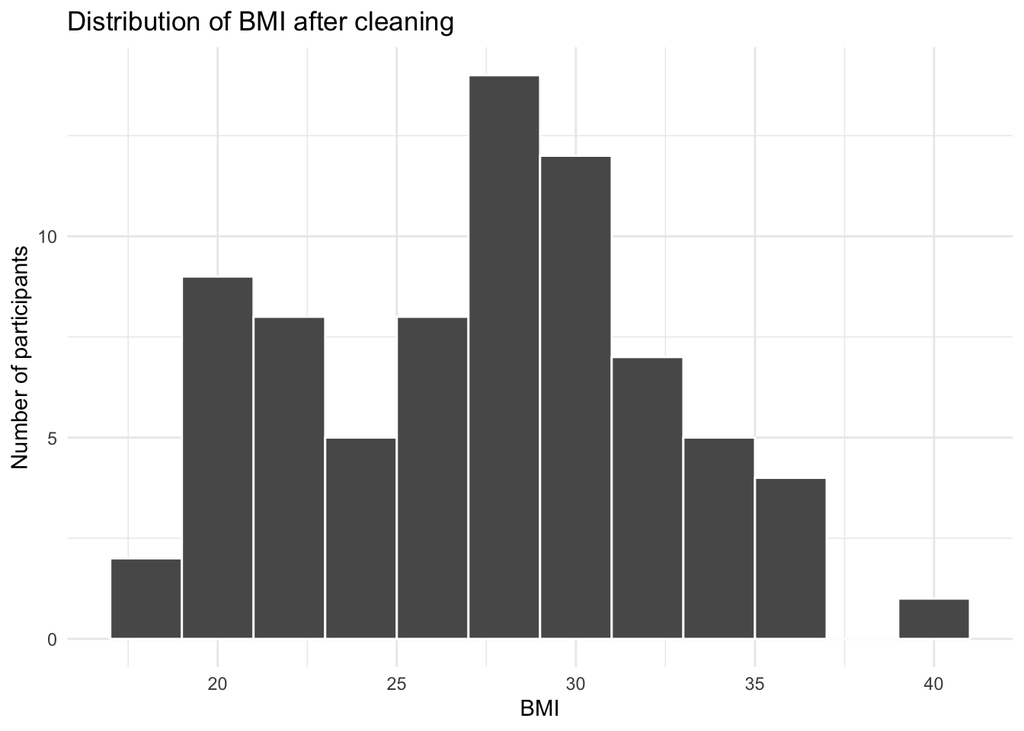

```r
# Plot the BMI distribution after cleaning.
ggplot(clean_data, aes(x = bmi)) +
  geom_histogram(binwidth = 2, colour = "white", na.rm = TRUE) +
  labs(
    title = "Distribution of BMI after cleaning",
    x = "BMI",
    y = "Number of participants"
  ) +
  theme_minimal()
```

## 21. Mini activity

Using the messy dataset, try to reproduce the cleaning workflow yourself.

1. Import the raw dataset.
2. Inspect the first few rows.
3. Clean column names.
4. Count missing values before cleaning.
5. Clean participant IDs and extra spaces.
6. Find duplicate participant IDs.
7. Convert numeric variables.
8. Standardise categorical variables.
9. Check impossible or suspicious values.
10. Save the cleaned dataset.

## 22. Common beginner mistakes

| Mistake | Why it matters |
| --- | --- |
| Overwriting the raw dataset | You lose the original record |
| Deleting all missing values too early | You may remove too much data without thinking |
| Assuming duplicate IDs are always errors | They may represent repeated visits or follow-up |
| Cleaning manually in Excel without a record | The work becomes hard to check or repeat |
| Changing values without documenting why | Later readers cannot understand your decisions |
| Ignoring variable types | Numbers stored as text cannot be analysed properly |
| Forgetting to save cleaning reports | You lose the audit trail of what changed |

## 23. What comes next?

Now that the dataset is clean, we can start asking research questions.

In Article 3, we will use the cleaned dataset to create descriptive summaries, build a simple Table 1, compare groups, and make cleaner exploratory figures.

## Appendix

You can download the files used in this article here:

1. [View all the files used to create this article on GitHub](https://github.com/Ziyao-Geng/RISE-Data-Science-Articles/tree/main/article_02_data_cleaning_in_r)
2. Download the sample messy health dataset
3. Download the Quarto file used to create this article